# Datajam2019

Christian Urcuqui

14 de marzo de 2019

# DataJam 2019 - Seguridad ciudadana

```r
library(ggplot2)
library(gmodels)
library(dplyr)
library(readxl)
library(GGally)
library(readr)
library(stringr)
library(ggmap)
library(colmaps)
```

Vamos a explorar la respuesta las siguientes pregunta para el año 2017

¿Cuales son los municipios que menos y más han presentado reportes de delitos? ¿Donde esta ubicado Cali en este ranking?

## Vamos a cargar las diferentes bases de datos 2017

Las bases de datos que se exploraron con fin de responder la pregunta ¿Cuáles son las variables de comunidades con baja tasa de criminalidad, y cómo promover su replicabilidad?

- Violencia
- 5 Datasets
- Dane / censo poblacional
- Información de la Alcaldía de Cali (Información no estructurada)
- Encuesta de Transición de la Escuela al Trabajo

```
##
##  FALSE   TRUE
## 613052      1
```

```
##
##  FALSE
## 613032
```

```
##
##  FALSE
## 239300
```

```
##
##   FALSE
## 3702100
```

```
##
##  FALSE
## 104420
```

```
##
##   FALSE
## 1345840
```

Integración con la base de datos de población del DANE

```
##
##  FALSE   TRUE
## 695947   1695
```

```
##
##  FALSE   TRUE
## 276340   5564
```

```
##
##   FALSE    TRUE
## 3959025   68565
```

```
##
##   FALSE    TRUE
## 1479091    2165
```

```
##
##  FALSE   TRUE
## 119851   9110
```

```
##
##  FALSE
## 693792
```

```
##
##  FALSE
## 274302
```

```
##
##   FALSE
## 2644803
```

```
##
##   FALSE
## 1475103
```

```
##
##  FALSE
## 118713
```

(reportes/poblacion_municipio)*100000

## Delitos sexuales

(reportes/poblacion_municipio)*100000

```
## [1] "Top 5 de menos indice de delitos sexuales"
```

```
##            Municipio                  Fecha Departamento   indice
## 21301  OLAYA HERRERA 09/28/2017 12:00:00 AM       NARIÑO 3.126368
## 27299      SANTACRUZ 01/03/2017 12:00:00 AM       NARIÑO 3.337450
## 23103       PINILLOS 08/21/2017 12:00:00 AM      BOLÍVAR 3.929582
## 24969  ROBERTO PAYAN 01/30/2017 12:00:00 AM       NARIÑO 4.169446
## 19973 MEDIO SAN JUAN 04/07/2017 12:00:00 AM        CHOCÓ 5.857888
## 29762         URIBIA 04/30/2017 12:00:00 AM      GUAJIRA 6.433213
```

```
## [1] "Top 5 de mayor indice de delitos sexuales"
```

```
##           Municipio                  Fecha Departamento    indice
## 20803        NARIÑO 11/19/2017 12:00:00 AM CUNDINAMARCA  1209.136
## 26660 SANTA BARBARA 10/14/2017 12:00:00 AM    ANTIOQUIA  1857.143
## 7844     BUENAVISTA 03/26/2017 12:00:00 AM      QUINDÍO  2159.050
## 14778       GRANADA 06/19/2017 12:00:00 AM         META  2384.369
## 25086   SABANALARGA 02/19/2017 12:00:00 AM    ATLÁNTICO 10473.557
## 1078        ARMENIA 02/15/2017 12:00:00 AM      QUINDÍO 11169.025
```

## Homicidios

[output not shown]

[output cut: 708 more lines]

[output not shown]

```
## < table of extent 0 >
```

```
## < table of extent 0 >
```

```
## [1] "Top 5 de menos indice de homicidios"
```

```
##       Municipio      Fecha Departamento    indice
## 4896       CHIA 27/08/2017 CUNDINAMARCA 0.7536306
## 11635  SOGAMOSO 05/09/2017       BOYACÁ 1.7811501
## 10625   SAN GIL 16/07/2017    SANTANDER 2.1856968
## 7293    LEBRIJA 08/06/2017    SANTANDER 2.4843486
## 875   BARRANCAS 03/06/2017      GUAJIRA 2.7674766
## 6246    GIGANTE 12/05/2017        HUILA 2.9061319
```

```
## [1] "Top 5 de mayor indice de homicidios"
```

```
##       Municipio      Fecha Departamento    indice
## 2507    BOLIVAR 13/10/2017        VALLE  616.8609
## 4350 CANDELARIA 06/02/2017        VALLE  622.6054
## 7064   LA UNION 19/08/2017    ANTIOQUIA  952.1838
## 2795 BUENAVISTA 08/04/2017      CÓRDOBA 1295.4300
## 404     ARGELIA 25/09/2017        VALLE 1736.5457
## 537     ARMENIA 21/02/2017      QUINDÍO 4417.9697
```

**Mayores indices de Homicidios 2017** + BOLIVAR 13/10/2017 VALLE 616.8609 + CANDELARIA 06/02/2017 VALLE 622.6054 + LA UNION 19/08/2017 ANTIOQUIA 952.1838 + BUENAVISTA 08/04/2017 CÓRDOBA 1295.4300 + ARGELIA 25/09/2017 VALLE 1736.5457 + ARMENIA 21/02/2017 QUINDÍO 4417.9697

## Hurto a personas

R/ Según los datos el municipio con el menores reportes de hurtos son: + ACHÍ ALEJANDRÍA + ALMAGUER + ANCUYÁ + ARBOLEDA + ASTREA

Los cinco municipios con la mayor cantidad de reportes son: + BUCARAMANGA (CT)  
+ PASTO (CT) BARRANQUILLA (CT)  
+ CALI (CT) (14708) + MEDELLÍN (CT)  
+ BOGOTÁ D.C. (CT) (65482)

```
## < table of extent 0 >
```

```
## [1] 0
```

```
## [1] "Top 5 de menos indice de hurtos"
```

```
##            Municipio                  Fecha Departamento   indice
## 81874   MEDIO ATRATO 12/04/2017 12:00:00 AM        CHOCÓ 3.178134
## 110224     SANTACRUZ 02/05/2017 12:00:00 AM       NARIÑO 3.337450
## 84015        MOÑITOS 01/06/2017 12:00:00 AM      CÓRDOBA 3.534318
## 96982       PINILLOS 05/14/2017 12:00:00 AM      BOLÍVAR 3.929582
## 104081 ROBERTO PAYAN 04/04/2017 12:00:00 AM       NARIÑO 4.169446
## 61582          MAGÜI 01/21/2017 12:00:00 AM       NARIÑO 4.189535
```

```
## [1] "Top 5 de mayor indice de hurtos"
```

```
##          Municipio                  Fecha Departamento   indice
## 104270 SABANALARGA 08/25/2017 12:00:00 AM    ATLÁNTICO 3552.680
## 84061     MOSQUERA 02/22/2017 12:00:00 AM CUNDINAMARCA 3600.579
## 60106     LA UNION 03/26/2017 12:00:00 AM    ANTIOQUIA 3978.173
## 102609    RIONEGRO 07/22/2017 12:00:00 AM    ANTIOQUIA 4977.511
## 52069      GRANADA 07/10/2017 12:00:00 AM         META 5265.482
## 19550       CALDAS 10/05/2017 12:00:00 AM    ANTIOQUIA 7943.662
```

**Menores indices de hurtos 2017**

- MEDIO ATRATO 12/04/2017 12:00:00 AM CHOCÓ 3.178134
- SANTACRUZ 02/05/2017 12:00:00 AM NARIÑO 3.337450
- MOÑITOS 01/06/2017 12:00:00 AM CÓRDOBA 3.534318
- PINILLOS 05/14/2017 12:00:00 AM BOLÍVAR 3.929582
- ROBERTO PAYAN 04/04/2017 12:00:00 AM NARIÑO 4.169446
- MAGÜI 01/21/2017 12:00:00 AM NARIÑO 4.189535

**Mayores indices de hurtos 2017** + SABANALARGA 08/25/2017 12:00:00 AM ATLÁNTICO 3552.680 + MOSQUERA 02/22/2017 12:00:00 AM CUNDINAMARCA 3600.579 + LA UNION 03/26/2017 12:00:00 AM ANTIOQUIA 3978.173 + RIONEGRO 07/22/2017 12:00:00 AM ANTIOQUIA 4977.511 + GRANADA 07/10/2017 12:00:00 AM META 5265.482 + CALDAS 10/05/2017 12:00:00 AM ANTIOQUIA 7943.662

## Violencia intrafamiliar

Los cinco municipios con la mayor cantidad de reportes son: + BUCARAMANGA (CT)  
+ POPAYÁN (CT)  
+ PASTO (CT)  
+ CALI (CT) 3244 + MEDELLÍN (CT) 5338 + BOGOTÁ D.C. (CT) 22088

```
##
## AGUA DE DIOS       ANCUYA       ATRATO      BELMIRA       BOJAYA
##            1            1            1            1            1
##     BUSBANZA
##            1
```

```
##
## BUCARAMANGA     POPAYAN       PASTO        CALI    MEDELLIN      BOGOTA
##        1161        1166        1348        3244        5338       22088
```

```
## [1] "Top 5 de menos indice de violencia intrafamiliar"
```

```
##           Municipio                  Fecha Departamento   indice
## 37088     EL CHARCO 04/02/2018 12:00:00 AM       NARIÑO 2.525253
## 36009      CUMARIBO 02/25/2018 12:00:00 AM      VICHADA 2.588394
## 50828  MEDIO ATRATO 05/09/2018 12:00:00 AM        CHOCÓ 3.178134
## 58265       REPELON 08/31/2018 12:00:00 AM    ATLÁNTICO 3.734409
## 59028 ROBERTO PAYAN 07/21/2018 12:00:00 AM       NARIÑO 4.169446
## 44856         MAGÜI 09/15/2018 12:00:00 AM       NARIÑO 4.189535
```

```
## [1] "Top 5 de mayor indice de violencia intrafamiliar"
```

```
##         Municipio                  Fecha Departamento    indice
## 52193      NARIÑO 09/20/2018 12:00:00 AM    ANTIOQUIA  1880.878
## 41110   GUADALUPE 09/04/2018 12:00:00 AM        HUILA  1889.661
## 51808    MOSQUERA 05/03/2018 12:00:00 AM CUNDINAMARCA  2037.627
## 40599     GRANADA 06/03/2018 12:00:00 AM         META  3609.670
## 59148 SABANALARGA 04/03/2018 12:00:00 AM    ATLÁNTICO  8295.887
## 1274      ARMENIA 04/08/2018 12:00:00 AM      QUINDÍO 12608.588
```

- EL CHARCO 04/02/2018 12:00:00 AM NARIÑO 2.525253
- CUMARIBO 02/25/2018 12:00:00 AM VICHADA 2.588394
- MEDIO ATRATO 05/09/2018 12:00:00 AM CHOCÓ 3.178134
- REPELON 08/31/2018 12:00:00 AM ATLÁNTICO 3.734409
- ROBERTO PAYAN 07/21/2018 12:00:00 AM NARIÑO 4.169446
- MAGÜI 09/15/2018 12:00:00 AM NARIÑO 4.189535

## Extorsión

```
##
##    ABEJORRAL       ABREGO      ACEVEDO AGUA DE DIOS        ALBAN
##            1            1            1            1            1
##    ALGARROBO
##            1
```

```
##
##        QUIBDO        CUCUTA VILLAVICENCIO          CALI        BOGOTA
##           109           130           159           294           426
##      MEDELLIN
##           460
```

```
## [1] "Top 5 de menos indice de extorción"
```

```
##              Municipio      Fecha Departamento   indice
## 3454           NECOCLI 27/07/2017    ANTIOQUIA 1.522928
## 5174            URIBIA 27/06/2017      GUAJIRA 1.608303
## 248            BARANOA 01/11/2017    ATLÁNTICO 1.695231
## 5311        VILLAMARIA 24/12/2017       CALDAS 1.709957
## 4010 PUERTO LIBERTADOR 04/12/2017      CÓRDOBA 1.970249
## 2184            GARZON 10/03/2017        HUILA 2.169527
```

```
## [1] "Top 5 de mayor indice de extorción"
```

```
##        Municipio      Fecha Departamento    indice
## 4915       SUCRE 09/03/2017    SANTANDER  218.2877
## 1639 CRAVO NORTE 17/07/2017       ARAUCA  245.1732
## 1038      CALDAS 25/07/2017    ANTIOQUIA  281.6901
## 2615    LA UNION 28/03/2017        VALLE  387.2558
## 5312  VILLANUEVA 28/01/2017      GUAJIRA  566.1713
## 2215     GRANADA 24/07/2017         META 1125.9521
```

**Menores indices de extorción 2017**

- NECOCLI 27/07/2017 ANTIOQUIA 1.522928
- URIBIA 27/06/2017 GUAJIRA 1.608303
- BARANOA 01/11/2017 ATLÁNTICO 1.695231
- VILLAMARIA 24/12/2017 CALDAS 1.709957
- PUERTO LIBERTADOR 04/12/2017 CÓRDOBA 1.970249
- GARZON 10/03/2017 HUILA 2.169527

**Mayores indices de extorción 2017** + SUCRE 09/03/2017 SANTANDER 218.2877 + CRAVO NORTE 17/07/2017 ARAUCA 245.1732 + CALDAS 25/07/2017 ANTIOQUIA 281.6901 + LA UNION 28/03/2017 VALLE 387.2558 + VILLANUEVA 28/01/2017 GUAJIRA 566.1713 + GRANADA 24/07/2017 META 1125.9521

## Enfoque hacia Cali

```
## [1] 59.62529
```

```
## [1] 50.98933
```

```
## [1] 134.0433
```

```
## [1] 12.14819
```

```
## [1] 607.74
```

Filtro de los indices para Cali teniendo en cuenta todos los datos de 2017

- Delitos sexuales, 59.62529
- Homicidios, 50.98933
- Familiar, 134.0433 **
- Extorsión, 12.14819
- Hurto, 607.74 ***

## El enfoque se realizará para educación

Encuesta Transición de la Escuela al Trabajo - ETET 2015

## Visualizaciones - Mapas

[output not shown]

[output not shown]

[output not shown]

[output not shown]

[output not shown]

[output not shown]

[output not shown]

[output not shown]

[output not shown]

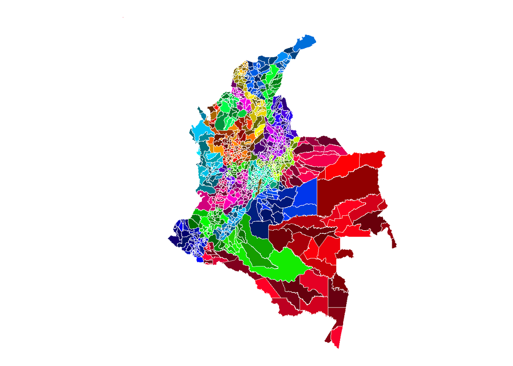

## Visualizaciones - Series de tiempo

[figure not shown]